# Hierarchical clustering

Prajwal C N

25 April 2021

### Problem Statement

The elementary public schools would like to choose a set of cereals to include in their daily cafeterias. Every day a different cereal is offered, but all cereals should support a healthy diet. The goal of this problem is to find the cluster of “healthy cereals.”

### Loading R libraries

```r
library(readr)
library(tidyverse)
library(cluster)
library(caret)
library(dendextend)
library(factoextra)
library(RColorBrewer)
```

### Importing Dataset

The dataset `Cereals.csv` includes nutritional information, store display, and consumer ratings for 77 breakfast cereals.

```r
Cereals <- read_csv("Cereals.csv")

# Examining the dataset
glimpse(Cereals)
```

```
## Rows: 77
## Columns: 16
## $ name     <chr> "100%_Bran", "100%_Natural_Bran", "All-Bran", "All-Bran_with_~
## $ mfr      <chr> "N", "Q", "K", "K", "R", "G", "K", "G", "R", "P", "Q", "G", "~
## $ type     <chr> "C", "C", "C", "C", "C", "C", "C", "C", "C", "C", "C", "C", "~
## $ calories <dbl> 70, 120, 70, 50, 110, 110, 110, 130, 90, 90, 120, 110, 120, 1~
## $ protein  <dbl> 4, 3, 4, 4, 2, 2, 2, 3, 2, 3, 1, 6, 1, 3, 1, 2, 2, 1, 1, 3, 3~
## $ fat      <dbl> 1, 5, 1, 0, 2, 2, 0, 2, 1, 0, 2, 2, 3, 2, 1, 0, 0, 0, 1, 3, 0~
## $ sodium   <dbl> 130, 15, 260, 140, 200, 180, 125, 210, 200, 210, 220, 290, 21~
## $ fiber    <dbl> 10.0, 2.0, 9.0, 14.0, 1.0, 1.5, 1.0, 2.0, 4.0, 5.0, 0.0, 2.0,~
## $ carbo    <dbl> 5.0, 8.0, 7.0, 8.0, 14.0, 10.5, 11.0, 18.0, 15.0, 13.0, 12.0,~
## $ sugars   <dbl> 6, 8, 5, 0, 8, 10, 14, 8, 6, 5, 12, 1, 9, 7, 13, 3, 2, 12, 13~
## $ potass   <dbl> 280, 135, 320, 330, NA, 70, 30, 100, 125, 190, 35, 105, 45, 1~
## $ vitamins <dbl> 25, 0, 25, 25, 25, 25, 25, 25, 25, 25, 25, 25, 25, 25, 25, 25~
## $ shelf    <dbl> 3, 3, 3, 3, 3, 1, 2, 3, 1, 3, 2, 1, 2, 3, 2, 1, 1, 2, 2, 3, 2~
## $ weight   <dbl> 1.00, 1.00, 1.00, 1.00, 1.00, 1.00, 1.00, 1.33, 1.00, 1.00, 1~
## $ cups     <dbl> 0.33, 1.00, 0.33, 0.50, 0.75, 0.75, 1.00, 0.75, 0.67, 0.67, 0~
## $ rating   <dbl> 68.40297, 33.98368, 59.42551, 93.70491, 34.38484, 29.50954, 3~
```

*Q1:* Applying hierarchical clustering to the data using Euclidean distance to the normalized measurements, and using Agnes to compare the clustering from single, complete, average, and Ward linkage methods and choosing the best method.

### Data Preparation

#### Data cleaning and Scaling

```r
# Checking NULL values in the dataset at column level.
colSums(is.na(Cereals))
```

```
##     name      mfr     type calories  protein      fat   sodium    fiber
##        0        0        0        0        0        0        0        0
##    carbo   sugars   potass vitamins    shelf   weight     cups   rating
##        1        1        2        0        0        0        0        0
```

```r
# Removing missing values which are present in the Cereals dataset
Cereals <- na.omit(Cereals)

# Using only the numerical variables for clustering
Cereals_numeric <- Cereals %>% select_if(is.numeric)
head(Cereals_numeric)
```

```
## # A tibble: 6 x 13
##   calories protein   fat sodium fiber carbo sugars potass vitamins shelf weight
##      <dbl>   <dbl> <dbl>  <dbl> <dbl> <dbl>  <dbl>  <dbl>    <dbl> <dbl>  <dbl>
## 1       70       4     1    130  10     5        6    280       25     3      1
## 2      120       3     5     15   2     8        8    135        0     3      1
## 3       70       4     1    260   9     7        5    320       25     3      1
## 4       50       4     0    140  14     8        0    330       25     3      1
## 5      110       2     2    180   1.5  10.5     10     70       25     1      1
## 6      110       2     0    125   1    11       14     30       25     2      1
## # ... with 2 more variables: cups <dbl>, rating <dbl>
```

```r
#Scaling the dataset using (Z-Score) standardization
Scaled_Cereals <- as.data.frame(scale(Cereals_numeric))
```

### Model Construction

From the problem statement, we infer that this problem falls under **Unsupervised Learning**. Hence I sought to use **Hierarchical Clustering** technique to find out the patterns and group similar objects into clusters.

Using Agnes method to compare the clustering from `Single`, `Complete`, `Average`, and `Ward` linkage methods.

```r
# methods to assess
m <- c( "average", "single", "complete", "ward")
names(m) <- c( "average", "single", "complete", "ward")
```

Defining a function to compute coefficient of the linkage methods. The function argument takes a `character vector(x)` as an input which matches the argument `method` of `agnes` function.

```r
ac <- function(x) {
  agnes(Scaled_Cereals, metric = "euclidean", method = x)$ac
}
```

Mapping character vector and `ac` function using map function which return the vector of linkage coefficients.

```r
map_dbl(m, ac)
```

```
##   average    single  complete      ward
## 0.7766075 0.6067859 0.8353712 0.9046042
```

From above Agnes function we can see that **ward linkage** has strong clustering structure, with agglomerative coefficient of **0.9**, So choosing **ward linkage method** for further cluster analysis.

*Q2:* Estimating the optimal number of clusters.

```r
# Hierarchical clustering using Ward Linkage
hc_cereals <- agnes(Scaled_Cereals, method = "ward")
```

#### Visualizing the Dendogram

Passing model object `hc_cereals` to `pltree` to produce `dendogram`.

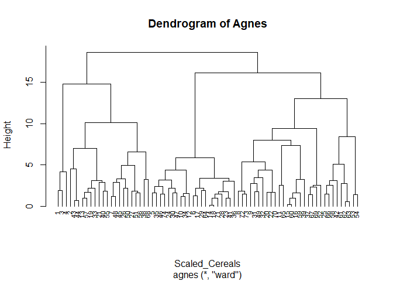

```r
pltree(hc_cereals, cex = 0.7, hang = -1, main = "Dendrogram of Agnes")
```

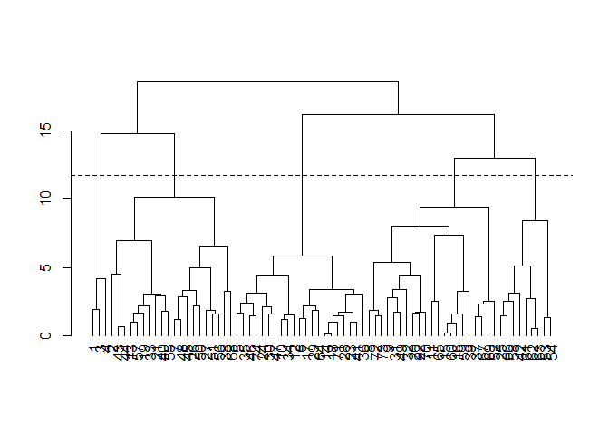

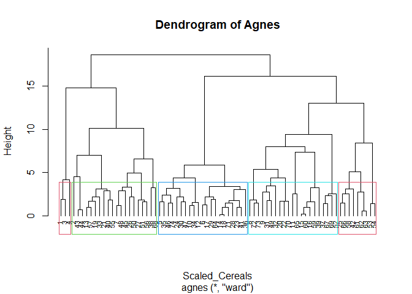

Hierarchical clustering is used to determine the optimal number of clusters. This optimal number of clusters can be determined by looking at the largest difference of heights. So from above analysis choosing optimal number of clusters **k = 5**

*Q3:* Checking Cluster stability

```r
# Cutting the tree
cluster_assignment <- cutree(hc_cereals, k=5)
cereals_clustered <- mutate(Scaled_Cereals, cluster = cluster_assignment)

# partitioning the cluster
set.seed(150)
index <- createDataPartition(cereals_clustered$cluster, p = 0.7, list = FALSE)
part_A <- cereals_clustered[index,]
part_B <- cereals_clustered[-index,]

# Finding cluster centroid for partition A
part_A_centroids <- part_A %>% gather("features","values",-cluster) %>%
  group_by(cluster,features) %>% summarise(mean_values = mean(values)) %>%
  spread(features,mean_values)

cluster_prediction_B <- data.frame(data=seq(1,nrow(part_B),1),
                                   Partition_B_cluster=rep(0,nrow(part_B)))

# Here row binding each test data datapoint to partition a centroids,
# and finding the minmum distance from each cluster centroid.
for (x in 1:nrow(part_B)) {
  cluster_prediction_B$Partition_B_cluster[x] <-

    which.min(as.matrix(get_dist(as.data.frame(
      rbind(part_A_centroids[-1], part_B[x, -length(part_B)])
    )))[6, -6])
}

# Comparing Partition B data labels  with the original data labels.
cluster_prediction_B <- cluster_prediction_B %>% mutate(original_clusters = part_B$cluster)
mean(cluster_prediction_B$Partition_B_cluster == cluster_prediction_B$original_clusters)
```

```
## [1] 1
```

As per the above analysis both the original and predicted clusters are matching. Hence conculding clusters have good stability.

*Q4:* Finding a cluster of “healthy cereals.”

Finding centroids of each cluster to determined the cluster characteristics.

```r
split_data <- split(cereals_clustered, cereals_clustered$cluster)
split_means <- lapply(split_data, colMeans)
(centroids <- do.call(rbind, split_means))
```

```
##     calories     protein        fat      sodium       fiber      carbo
## 1 -2.2018711  1.38174776 -0.3310734  0.17279012  3.64131237 -2.0718749
## 2  0.8553248  0.59163927  0.9435592 -0.08898011  0.38141771 -0.2003584
## 3  0.1978117 -0.91996886  0.0000000  0.12101140 -0.66198437 -0.5423583
## 4 -0.1621407  0.18662567 -0.4729620  0.77112209 -0.21003997  0.9626860
## 5 -1.2499969 -0.06420242 -0.8828625 -1.94150793 -0.02664224  0.1551013
##       sugars     potass    vitamins      shelf     weight       cups     rating
## 1 -0.7894824  2.9837813 -0.18184220  0.9419715 -0.2008324 -1.8452553  2.2426479
## 2  0.5143002  0.7475659  0.09849786  0.8217889  0.9235649 -0.5477863 -0.2928786
## 3  0.9583619 -0.7415648 -0.18184220 -0.6604628 -0.2008324  0.2779676 -0.9636465
## 4 -0.8659505 -0.3485391  0.45893508 -0.1453946 -0.2008324  0.4577648  0.2916795
## 5 -1.0953551 -0.1122758 -0.80482011 -0.2598542 -1.0482044  0.1156788  1.4712151
##   cluster
## 1       1
## 2       2
## 3       3
## 4       4
## 5       5
```

**Visualizing the clusters**

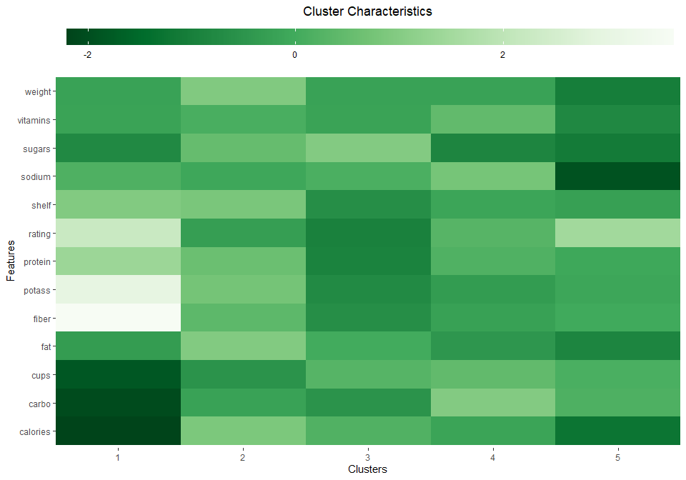

```r
hm.palette <-
  colorRampPalette(rev(brewer.pal(9, 'Greens')), space = 'Lab')
data.frame(centroids) %>% gather("features", "values",-cluster) %>%
  ggplot(aes(
    x = factor(cluster),
    y = features,
    fill = values
  )) +
  geom_tile() + theme_classic() +
  theme(
    axis.line = element_blank(),
    legend.position = "top",
    legend.justification = "left",
    plot.title = element_text(hjust = 0.5),
    legend.title = element_blank(),
    legend.key.width = unit(4.5, "cm")
  ) +
  scale_x_discrete(expand = c(0, 0)) +
  scale_fill_gradientn(colours = hm.palette(100)) +
  labs(title = "Cluster Characteristics",
       x = "Clusters",
       y = "Features",
       fill = "Centroids")
```

Some type of cereals are healthier than others. Few Cereals are generally marketed towards children and are sometimes made up of 50% sugar, the packaging of that products can also be misleading because they boast only their good qualities, such as added fibers or essential vitamins. Healthy cereals,however are not coated in sugar or available in fun colors of shapes. Studies show that less sugar, less sodium and more fiber are good for kids and adults.

**From the above cluster analysis and facts we can infer that cluster1 is healthy for kids. So this can be recommended for elementary public schools in their daily meals**

**and we have to normalize the data so that the scale of each variable is the same. If the scale of the variables is not the same, the model might become biased towards the variables with a higher magnitude.**

*Note:*  
The above domain information is referred from the below link  
http://www.historyofcereals.com/cereal-facts/types-of-cereals/